# Bonanza Snowshoe Hares

Kiera Matiska

11/5/2021

# Introduction

# Data and Analyses

The data set used in this report has 3197 obesrvations of hare individuals between three sites. These sites are Bonanza Riparian, Bonanza Mature Forest, and Bonanza Lowland Mature Forest. Each observation contains data on the age, sex, weight (g), hind foot length (mm), site, left and right ear tags, date, and trap ID. For this report, calculations using t-tests, summary tables, Cohen’s *d* tests, and Pearson’s R test are analzyed. Data is also represented clearly in a table and over a multitude of different graphs.

## Citations

Kielland, K., F.S. Chapin, R.W. Ruess, and Bonanza Creek LTER. 2017. Snowshoe hare physical data in Bonanza Creek Experimental Forest: 1999-Present ver 22. Environmental Data Initiative. https://doi.org/10.6073/pasta/03dce4856d79b91557d8e6ce2cbcdc14

National Parks Service. 2021. NETN Species Spotlight - Snowshoe Hare. National Parks Service. https://www.nps.gov/articles/netn-species-spotlight-snowshoe-hare.htm

# 1. Annual Juvinile Hare Trap Counts

### Visualize Data

Create a column graph plotting year (x-axis) against number of traps (y-axis).

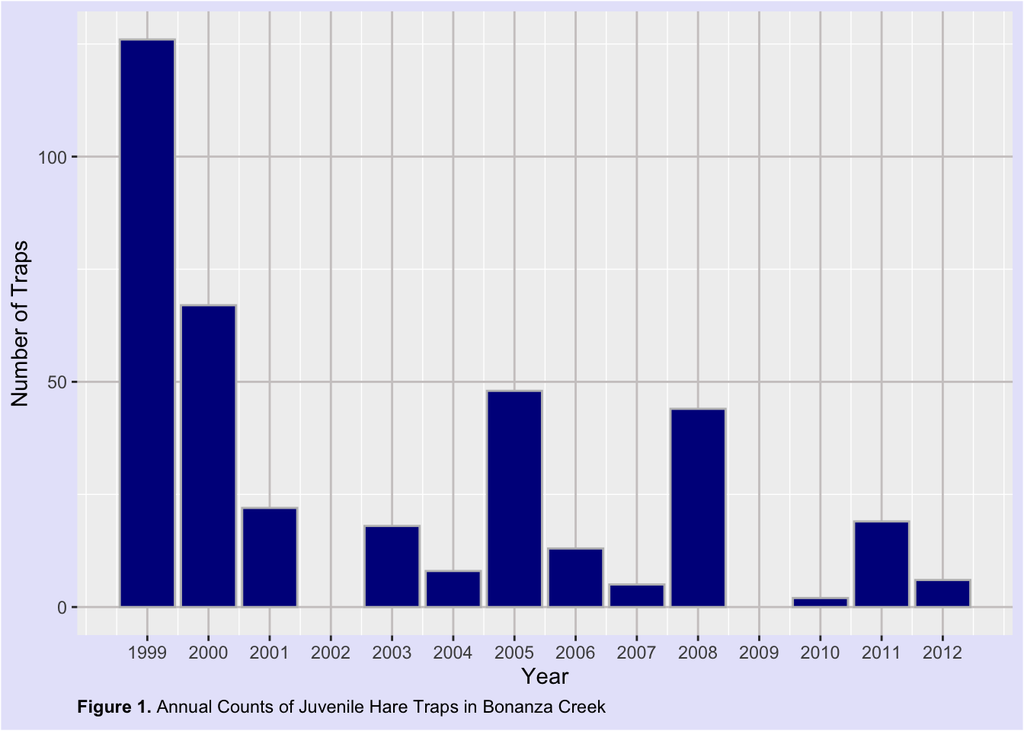

## Major Takeaways

# 2. Juvenile Hare Weights

### Data Visualization

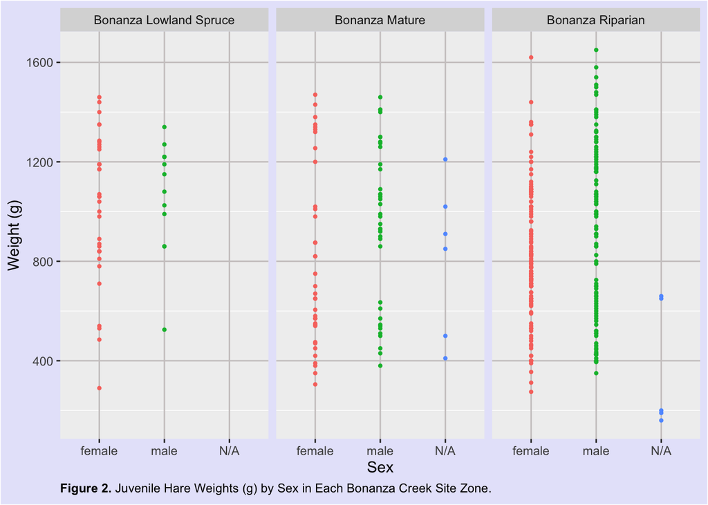

The first site (‘Bonanza Lowland Spruce’) is the site used for monitoring abundance and survival of snowshoe hares via live-trapping them. The second site (‘Bonanza Mature’) consists of mature white spruce, alder, paper birch, and black spruce trees. The last site (‘Bonanza Riparian’) is the flood zone area of the creek nearby the Tanana River and the Bonanza Mature Black Spruce

## Major Takeaways

# 3. Juvenile Weight Comparisons (male and female snowshoe hares)

### Summarize Data

Create and finalize a summary table that contains the mean, standard deviation, and sample size for male and female juvenile hares

- Use the `summarize` and `group_by` functions to find weight statistics based on sex
- Use `kableExtra` to finalize table and add table caption

Table 1: Mean, Standard Deviation, and Sample Sizes of Weights by Sex of Juvenile Hares

| Sex | Minimum Weight (g) | Maximum Weight (g) | Mean Weight (g) | Median Weight (g) | Standard Deviation | Sample Size |
| --- | --- | --- | --- | --- | --- | --- |
| female | 275 | 1620 | 855.39 | 825 | 292.25 | 200 |
| male | 350 | 1650 | 945.86 | 990 | 333.22 | 163 |

## Key Takeaways

Between male and female juvenile hares, on average, male hares are larger than female hares by 91 grams. The effect size was small based on the Cohen’s *d* value of 0.2904674 and the unpaired t-test resulted in a p-value of 0.0070933. This p-value means that there is a 0.7093279% chance of finding sample means that are at least this different if drawn, by random chance, from populations with the same mean weight.

# 4. Relationship Between Juvenile Weight and Hind Foot Length

### Data Visualization

Create a scatter plot using `geom_point()` that plots weight (x-axis) against hind foot length (y-axis)

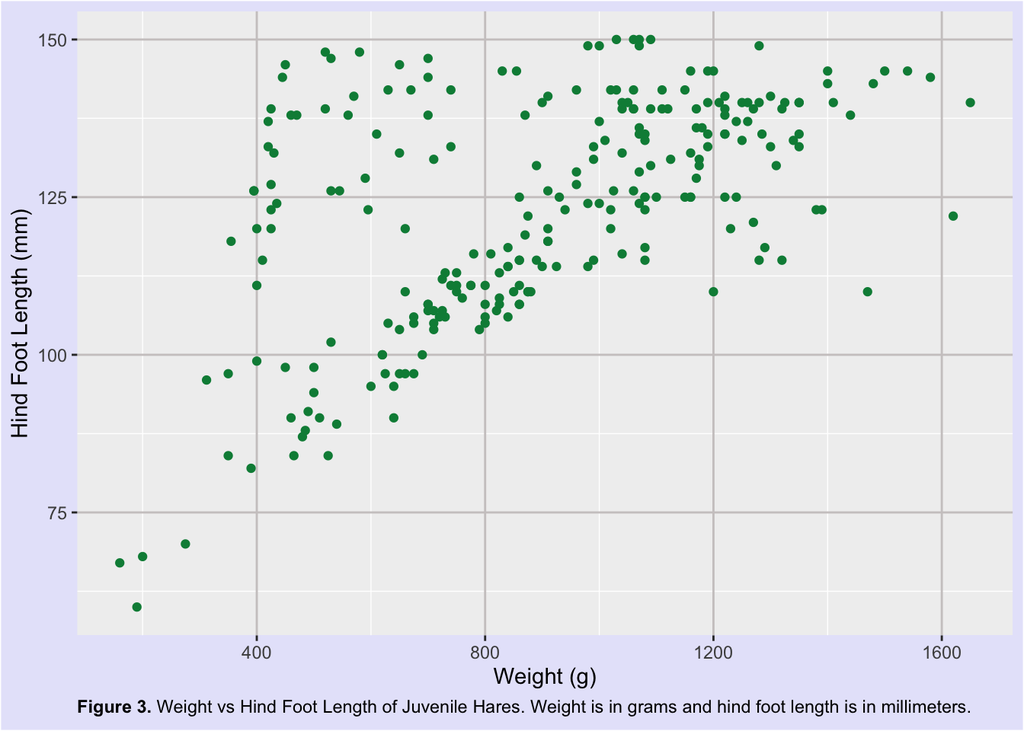

## Key Takeaways

For this section on the relationship between weight (g) and hind foot length (mm), it appears that there is a positive correlation between hind foot length and weight. For the linear regression model test, the hind foot coefficient is 9.52. This value means that with every 1 mm increase in hind foot length, the weight of the hare increases by 9.52 grams on average. Additionally, the R^2 value is 0.299. The meaning of this value is that 29.9% of variance in hare weight is explained by hind foot length. The Pearson’s *r* value of 0.55 means that there is a moderate correlation between hind foot length and hare weight. The assumptions of linear regression that may be of concern from this is homoscedesticity because the variances are unequal.

# Summary

To summarize this report, we found:

- that hare traps decreased from 1999 to 2012, showing a possible decrease in effort of the trapping and re-capturing program of snowshoe hares
- that there was a higher abundance of hares among the Bonanza Riparian Site
- that female juvenile hares were, on average, slightly smaller than male juvenile hares
- that there is a moderate, positive correlation between hind foot length (mm) and snowshoe hare weight (g)

# Citations

David Robinson, Alex Hayes and Simon Couch (2021). broom: Convert Statistical Objects into Tidy Tibbles. R package version 0.7.9. https://CRAN.R-project.org/package=broom

Garrett Grolemund, Hadley Wickham (2011). Dates and Times Made Easy with lubridate. Journal of Statistical Software, 40(3), 1-25. URL https://www.jstatsoft.org/v40/i03/.

Hao Zhu (2021). kableExtra: Construct Complex Table with ‘kable’ and Pipe Syntax. R package version 1.3.4. https://CRAN.R-project.org/package=kableExtra

Kielland, K., F.S. Chapin, R.W. Ruess, and Bonanza Creek LTER. 2017. Snowshoe hare physical data in Bonanza Creek Experimental Forest: 1999-Present ver 22. Environmental Data Initiative. https://doi.org/10.6073/pasta/03dce4856d79b91557d8e6ce2cbcdc14

Kirill Müller (2020). here: A Simpler Way to Find Your Files. R package version 1.0.1. https://CRAN.R-project.org/package=here

National Parks Service. 2021. NETN Species Spotlight - Snowshoe Hare. National Parks Service. https://www.nps.gov/articles/netn-species-spotlight-snowshoe-hare.htm

R Core Team (2021). R: A language and environment for statistical computing. R Foundation for Statistical Computing, Vienna, Austria. URL https://www.R-project.org/.

RStudio Team (2021). RStudio: Integrated Development Environment for R. RStudio, PBC, Boston, MA URL http://www.rstudio.com/.

Torchiano M (2020). *effsize: Efficient Effect Size Computation*. doi: 10.5281/zenodo.1480624 (URL: https://doi.org/10.5281/zenodo.1480624), R package version 0.8.1, <URL: https://CRAN.R-project.org/package=effsize>.

Wickham et al., (2019). Welcome to the tidyverse. Journal of Open Source Software, 4(43), 1686, https://doi.org/10.21105/joss.01686